# Introducción a la programación y análisis de datos en R

Día 4 · Bloque 2 — Reportes reproducibles

Filip Andras

CIMCYC — Universidad de Granada

30 octubre 2026

## Mapa del día 4

Bloque 1  
9:00 – 10:30

Visualización de datos

La gramática de `ggplot2`

Un gráfico paso a paso

Ej. 1

Otros gráficos del ensayo

Bloque 2  
11:00 – 12:30

Quarto: reportes reproducibles

Crear un documento: YAML, chunks, Markdown

Ej. 2

Se presenta el Ej. 3 (final)

Cierre del curso

Bloque 3  
13:00 – 14:00 · 60’

Ej. 3 (final): el informe del ensayo

Comentarios, preguntas, siguientes pasos

# Quarto: reportes reproducibles

## Flujo de trabajo

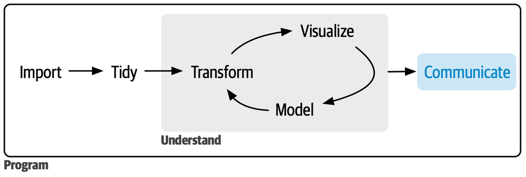

## La escritura de informes: procesadores de texto

[figure not shown]

[figure not shown]

## La escritura de informes: Procesadores vs. Quarto

**Procesadores de texto**

- Ejecutas análisis en R
- Copias números a Word/Excel
- Copias y pegas los gráficos
- Formato manual (e.g., negrita, tamaño)
- Encuentras un error
- ¡Empiezas de cero!

**Quarto**

- Escribes texto + código juntos
- Un clic para renderizar (compilar el texto/codigo/resultados)
- Números, tablas y gráficos se actualizan automáticamente
- Facilita la colaboración
- Transparente y Reproducible

**Tip**

Este curso entero está escrito en Quarto. Cada slide es un documento `.qmd`.

## Quarto potencia la comunicación efectiva

- [Quarto Gallery](https://quarto.org/docs/gallery/#presentations)
  - Artículos
  - Presentaciones
  - Dashboards
  - Websites
  - Libros
  - Documentos interactivos
- Ejemplo

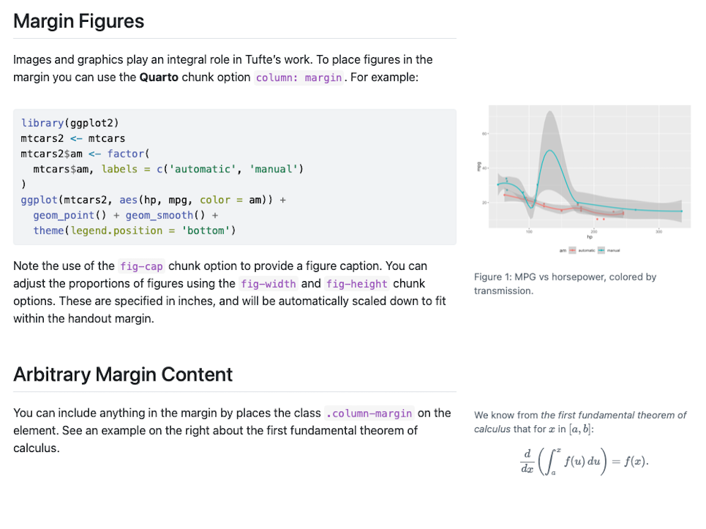

## ¿Qué es Quarto?

- **Sistema** de publicación que combina **texto** y **código** en un solo documento
- Escribe en **Markdown** (sintaxis de formato simple) + chunks de código R
- Genera archivos en **HTML**, **PDF** o **Word**, **presentaciones** (con un clic)
- Sucesor de R Markdown — funciona con R, Python, Julia

[figure not shown]

## Estructura básica de un documento de Quarto

1. **YAML header** (para configurar el documento), entre dos líneas `---`
2. **Texto** en formato *Markdown*: `# Encabezado`, `**negrita**`, listas, enlaces…
3. **Chunks** de código R, entre `` ```{r} `` y `` ``` ``: se ejecutan al renderizar y su resultado se inserta en ese punto

````markdown
---
title: "Informe del ensayo clínico"
author: "Tu nombre"
lang: es
format: html
---

# Introducción

El ensayo incluye **300 pacientes** en tres grupos.

```{r}
library(tidyverse)
data_trial <- read_csv("data/data_clinical_trial.csv")
```

## Ansiedad tras el tratamiento

```{r}
ggplot(data_trial, aes(x = group, y = anxiety_post)) +
  geom_boxplot()
```

Como muestra el gráfico, el grupo control queda por encima.
````

## Qué pasa al pulsar `Render`

- **`.qmd`**: el fichero que escribes, texto + chunks de código R
- **`knitr`** ejecuta los chunks y el código en línea, y pega los resultados (números, tablas, figuras) en el texto. Sale un `.md`: solo texto y resultados, ya sin código que ejecutar
- **`pandoc`** convierte ese Markdown al formato final: HTML, Word, PDF… el que pida el YAML
- Tú solo pulsas **Render**: los dos pasos ocurren por detrás, en una sesión de R nueva y vacía. Por eso el `.qmd` tiene que cargar él mismo los paquetes y los datos

## Crear un documento Quarto (lo hacemos juntos/as)

- En RStudio: **File > New File > Quarto Document**
- Revisar el YAML: Elige título, autor y formato de salida (HTML recomendado para empezar)
- Guardar el documento. El archivo tiene extensión `.qmd`
- Dos modos de edición: **Source** (texto plano) y **Visual** (editor WYSIWYG: *“What You See Is What You Get”*)
- Renderizar: botón **Render** o `Ctrl/Cmd + Shift + K`

## Parte 1. El encabezado YAML

```yaml
---
title: "Informe del ensayo clínico"
author: "Tu Nombre"
date: "2026-10-30"
lang: es
format:
  html:
    toc: true
    embed-resources: true
---
```

- `title`, `author`, `date` — metadatos del documento
- `lang: es` — “Figura”, “Tabla”, fechas… en español
- `format: html` — formato de salida
- `toc: true` — tabla de contenidos automática
- `embed-resources: true` — un solo archivo HTML autocontenido (sin carpeta de dependencias): se puede enviar por correo

**Importante**

El espaciado (sangría) importa: dos espacios por nivel (en RStudio, pulsar *Tab* escribe esos dos espacios)

## Parte 2. Chunks de código R

````markdown
```{r}
#| echo: true
#| eval: true
#| code-fold: true

library(tidyverse)
ggplot(data = data_trial,
       mapping = aes(x = group, y = anxiety_post,
                     fill = group)) +
  geom_boxplot()
```
````

- Insertar chunks: **Cmd/Ctrl** + **Shift** + **I** (o *Insert* > *Executable Cell*)
- El código se ejecuta al renderizar, y su resultado (texto, tabla, gráfico) aparece debajo
- Las opciones van al principio, tras `#|`:
  - `echo: true` — mostrar el código
  - `eval: true` — ejecutar el código
  - `code-fold: true` — código plegado (botón “Código”)
  - `fig-width` / `fig-height` — tamaño de la figura en pulgadas
  - `warning: false` — ocultar avisos

## Parte 2. Opciones de chunk más útiles

| Opción | Qué hace |
| --- | --- |
| `echo: true/false` | Mostrar/ocultar código |
| `eval: true/false` | Ejecutar/saltar código |
| `warning: false` | Ocultar advertencias |
| `message: false` | Ocultar mensajes de carga |
| `code-fold` | El código se (des)pliega |
| `fig-width: 7` | Anchura de la figura (pulgadas) |
| `fig-height: 5` | Altura de la figura (pulgadas) |
| `fig-cap: "Titulo"` | Pie de figura |
| `tbl-cap: "Titulo"` | Pie de tabla |

## El error clásico: “en la consola funciona, pero Render falla”

- Al renderizar, Quarto ejecuta el documento en una **sesión nueva de R**, vacía: como después de `Restart R` (día 1)
- Lo que tengas en tu *Environment* **no existe** para el documento: el `.qmd` tiene que cargar él mismo los paquetes y los datos, en un chunk al principio
- Las rutas, con `here()` desde el proyecto (día 2): el documento se renderiza igual en tu ordenador y en el de tu colaborador/a
- Si falla, el error dice el chunk: `Quitting from lines 23-31`

## Parte 2: Extra — código en línea (*inline code*)

Los números del texto salen de los datos: si cambian los datos, cambian los números al renderizar.

```r
# en un chunk: calcular y guardar
n_pacientes <- nrow(data_trial)
media_post  <- data_trial |>
  group_by(group) |>
  summarise(media = round(mean(anxiety_post), 1))
```

```r
El ensayo incluye `r n_pacientes` pacientes. Tras el tratamiento, la ansiedad
media del grupo CBT fue `r media_post$media[media_post$group == "CBT"]` puntos.
```

> El ensayo incluye 300 pacientes. Tras el tratamiento, la ansiedad media del grupo CBT fue 10.8 puntos.

## Código en línea (2): el resultado del test en el texto

```r
anova_mixto <- aov_car(anxiety ~ group * momento + Error(patient_id / momento), data = datos_largo)
tabla_mixto <- summary(anova_mixto)$univariate.tests   # la tabla del summary(), guardada como objeto
tabla_mixto
```

```
              Sum Sq num Df Error SS den Df   F value                Pr(>F)
(Intercept)   120825      1  3152.77    297 11382.047 < 0.00000000000000022 ***
group            637      2  3152.77    297    29.995     0.000000000001365 ***
momento         1016      1   382.74    297   788.061 < 0.00000000000000022 ***
group:momento    358      2   382.74    297   138.910 < 0.00000000000000022 ***
---
Signif. codes:  0 '***' 0.001 '**' 0.01 '*' 0.05 '.' 0.1 ' ' 1
```

```r
tabla_mixto["group:momento", "F value"]   # [fila, columna], como el dia 1
```

```
[1] 138.9096
```

- La tabla es una matriz: cada número se saca con `[fila, columna]`, y eso es lo que va dentro del código en línea

## Código en línea (3): la frase del informe

Lo que se escribe en el `.qmd`:

```r
La interacción grupo × momento es significativa,
*F*(`r tabla_mixto["group:momento", "num Df"]`, `r tabla_mixto["group:momento", "den Df"]`) =
`r round(tabla_mixto["group:momento", "F value"], 2)`,
*p* `r format.pval(tabla_mixto["group:momento", "Pr(>F)"], eps = 0.001)`.
```

Lo que sale al renderizar:

> La interacción grupo × momento es significativa, *F*(2, 297) = 138.91, *p* < 0.001.
- `round(x, 2)` redondea la *F*; `format.pval(eps = 0.001)` escribe “<0.001” en vez de 0.0000000000000002
- Si cambian los datos, al renderizar cambian los números del texto

## Parte 3. El texto: sintaxis Markdown (Source vs. Visual)

```markdown
# Informe del ensayo

## Métodos

Participaron **300 pacientes** en *tres* grupos:

- Terapia cognitivo-conductual (CBT)
- Tratamiento farmacológico
    - 12 semanas
- Control

[Datos y código](https://cimcyc.ugr.es)
```

## Informe del ensayo

#### Métodos

Participaron **300 pacientes** en *tres* grupos:

- Terapia cognitivo-conductual (CBT)
- Tratamiento farmacológico
  - 12 semanas
- Control

[Datos y código](https://cimcyc.ugr.es)

- **Encabezados**: `#` nivel 1, `##` nivel 2, `###` nivel 3… (las secciones de la tabla de contenidos)
- **Énfasis**: `**negrita**`, `*cursiva*`
- **Listas**: una línea por `-`; cuatro espacios de sangría = subnivel
- **Enlaces**: `[texto](url)`

## Parte 3. Más sintaxis Markdown

| Sintaxis | Se convierte en… |
| --- | --- |
| `Texto plano` | Texto plano |
| `*cursiva* o _cursiva_` | *cursiva* o *cursiva* |
| `**negrita** o __negrita__` | **negrita** o **negrita** |
| `**_negrita y cursiva_**` | *negrita y cursiva* |
| `superíndice^2^` | superíndice<sup>2</sup> |
| `~~texto tachado~~` | texto tachado |
| `[link](www.rstudio.com)` | link |
| `ecuación: $A = \pi*r^{2}$` | ecuación: $A = \pi*r^{2}$ |
| `![](img/ansiedad_post_por_grupo.png)` |  |

## Tablas (1): la Tabla 1 del día 2 con `knitr::kable()`

```r
# la tabla de group_by() + summarise() del dia 2...
tabla_1 <- data_trial |>
  group_by(group) |>
  summarise(n          = n(),
            media_pre  = round(mean(anxiety_pre), 1),
            dt_pre     = round(sd(anxiety_pre), 1),
            media_post = round(mean(anxiety_post), 1),
            dt_post    = round(sd(anxiety_post), 1))

# ...convertida en una tabla de informe (en la consola seria un tibble)
knitr::kable(tabla_1,
             col.names = c("Grupo", "n", "Media pre", "DT pre", "Media post", "DT post"))
```

| Grupo | n | Media pre | DT pre | Media post | DT post |
| --- | --- | --- | --- | --- | --- |
| CBT | 100 | 15.1 | 2.1 | 10.8 | 2.8 |
| control | 100 | 15.7 | 2.1 | 15.2 | 2.5 |
| pharmacological | 100 | 15.7 | 2.2 | 12.7 | 2.7 |

## Tablas (2): la Tabla 1 automática con `gtsummary`

```r
# install.packages("gtsummary")
library(gtsummary)

data_trial |>
  select(group, sex, age,
         anxiety_pre, anxiety_post) |>
  tbl_summary(
    by        = group,
    statistic = all_continuous() ~
                "{mean} ({sd})",
    label     = list(
      sex          ~ "Sexo",
      age          ~ "Edad",
      anxiety_pre  ~ "Ansiedad pre",
      anxiety_post ~ "Ansiedad post"))
```

| **Characteristic** | **CBT** N = 100<sup>1</sup> | **control** N = 100<sup>1</sup> | **pharmacological** N = 100<sup>1</sup> |
| --- | --- | --- | --- |
| Sexo |  |  |  |
| female | 54 (54%) | 74 (74%) | 54 (54%) |
| male | 46 (46%) | 26 (26%) | 46 (46%) |
| Edad | 42 (11) | 42 (12) | 42 (11) |
| Ansiedad pre | 15.08 (2.14) | 15.74 (2.14) | 15.66 (2.19) |
| Ansiedad post | 10.8 (2.8) | 15.2 (2.5) | 12.7 (2.7) |

<sup>1</sup> n (%); Mean (SD)

- `by`: una columna por grupo. Cuenta, resume y formatea sola: numéricas con media (DT), categóricas con n (%)
- `statistic`: qué estadístico mostrar y con qué formato
- `label`: los nombres de las variables tal como deben salir en la tabla
- Otras: [`kableExtra`](https://haozhu233.github.io/kableExtra/) (estilo sobre `kable`), [`gt`](https://gt.rstudio.com/), [`flextable`](https://davidgohel.github.io/flextable/) (Word)

## Figuras y tablas numeradas: referencias cruzadas

````markdown
```{r}
#| label: fig-ansiedad
#| fig-cap: "Ansiedad tras el tratamiento por grupo"
grafico_ansiedad
```

Como muestra la @fig-ansiedad, el grupo control...

```{r}
#| label: tbl-descriptivos
#| tbl-cap: "Características de la muestra por grupo"
tabla_1 |> knitr::kable()
```

La @tbl-descriptivos resume la muestra.
````

- `label: fig-...` + `fig-cap:` numera la figura (“Figura 1”) y pone el pie; `tbl-...` + `tbl-cap:`, lo mismo con tablas
- `@fig-ansiedad` en el texto se convierte en “Figura 1” con enlace; si insertas otra figura antes, se renumeran solas

## Bibliografía (1): citar con `[@clave]`

```markdown
---
title: "Clinical trial report"
bibliography: references.bib
csl: apa.csl
---

Anxiety was measured with the BAI [@beck1988].
Pairwise comparisons used the Holm
correction [@holm1979; @rcore].
As @beck1988 showed, the BAI is reliable.

## References

::: {#refs}
:::
```

- `references.bib`: la base de datos, en formato **BibTeX**: un bloque por referencia, con su **clave** (`@article{beck1988, author = ..., year = ...}`)
- `apa.csl`: la **hoja de estilo** (APA 7); hay miles en zotero.org/styles. Cambias el archivo y todo el documento cambia de estilo
- `[@clave]` → (Beck et al., 1988); varias con `;` → (Holm, 1979; R Core Team, 2026)
- Sin corchetes → cita narrativa: Beck et al. (1988)
- La lista de referencias se genera sola, solo con lo citado, donde pongas el div `#refs` (si no, al final)

## Bibliografía (2): de dónde salen las referencias

- **Zotero** → seleccionar ítems o colección → *Export* → formato **BibTeX** → `references.bib`. Con el plugin *Better BibTeX*: claves legibles y estables, y el `.bib` se actualiza solo
- **Editor Visual** de RStudio → *Insert* → *Citation*: busca en tu Zotero, añade la entrada al `.bib` y la cita al texto en un clic
- **Los paquetes se citan solos**: `citation()` da la referencia de R, `citation("ggplot2")` la del paquete, y `toBibtex()` la convierte en BibTeX para pegarla en el `.bib` (solo falta ponerle la clave)

```r
# la cita de un paquete, lista para el .bib
toBibtex(citation("ggplot2"))
```

```
@Book{,
  author = {Hadley Wickham},
  title = {ggplot2: Elegant Graphics for Data Analysis},
  publisher = {Springer-Verlag New York},
  year = {2016},
  isbn = {978-3-319-24277-4},
  url = {https://ggplot2.tidyverse.org},
}
```

## Pestañas: `panel-tabset`

````markdown
::: {.panel-tabset}

### Boxplot

```{r}
grafico_ansiedad
```

### Pre y post

```{r}
grafico_pre_post
```

### Tabla

```{r}
knitr::kable(tabla_1)
```

:::
````

Una pestaña por `###` dentro del div. El lector elige qué pestaña ver y el informe no se alarga. `grafico_ansiedad`, `grafico_pre_post` y `tabla_1` son objetos creados antes.

- Boxplot
- Pre y post
- Tabla

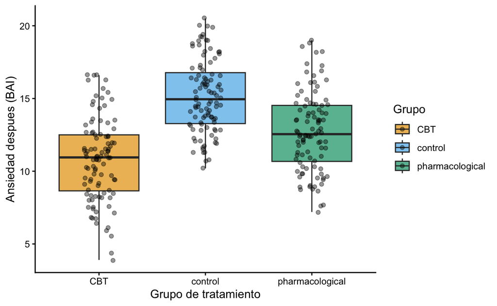

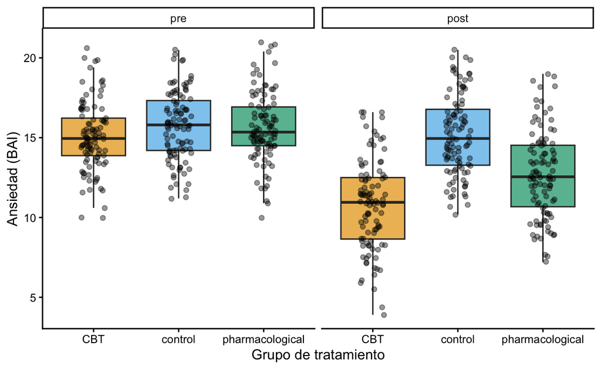

| Grupo | n | Media pre | DT pre | Media post | DT post |
| --- | --- | --- | --- | --- | --- |
| CBT | 100 | 15.1 | 2.1 | 10.8 | 2.8 |
| control | 100 | 15.7 | 2.1 | 15.2 | 2.5 |
| pharmacological | 100 | 15.7 | 2.2 | 12.7 | 2.7 |

## No solo R: Python y Julia en el mismo documento

````markdown
```{python}
import pandas as pd
datos = pd.read_csv("data/raw_data/data_clinical_trial.csv")
datos.groupby("group")["anxiety_post"].mean()
```
````

````markdown
```{julia}
using CSV, DataFrames, Statistics
datos = CSV.read("data/raw_data/data_clinical_trial.csv", DataFrame)
combine(groupby(datos, :group), :anxiety_post => mean)
```
````

- El motor de Quarto no es R: un chunk `{python}` o `{julia}` se ejecuta con ese lenguaje (hacen falta instalados; Python vía `reticulate` o Jupyter, Julia vía Jupyter o `JuliaCall`)
- Un mismo `.qmd` puede mezclar lenguajes: el preprocesado en Python, el modelo en R, la figura en lo que prefieras
- También Observable JS para gráficos interactivos

## Renderizar a distintos formatos de salida

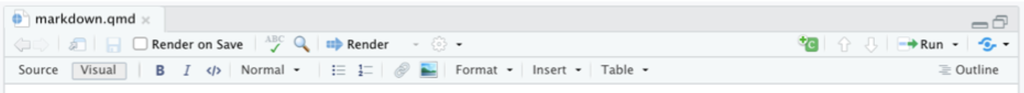

- `format: html` — informe web (recomendado para empezar); `embed-resources: true` para un solo archivo
- `format: docx` — Word, editable por cualquier persona; con `reference-doc: plantilla.docx` sale con los estilos de la revista
- Manuscrito **APA 7** listo para enviar: en la Terminal, `quarto use template wjschne/apaquarto` crea el proyecto con la plantilla [apaquarto](https://wjschne.github.io/apaquarto/): Word, PDF y HTML en formato APA, con tablas y figuras numeradas
- `format: pdf` — requiere LaTeX (instalar con `tinytex::install_tinytex()`)
- `format: revealjs` — presentación de diapositivas (¡como este curso!)
- `format: dashboard` — panel interactivo
- Un mismo `.qmd` puede renderizarse a múltiples formatos

# Ejercicio 2

## Ejercicio 2 — Tu primer informe Quarto

Tiempo: 20 minutos

1. Crea un documento de Quarto: **File > New File > Quarto Document**, y guárdalo como `informe_ensayo.qmd` en la carpeta `exercises/`
2. Revisa el YAML: tu nombre, `lang: es`, `toc: true` y `embed-resources: true`
3. Escribe un encabezado `# Informe del ensayo clínico` y una frase de introducción
4. Añade chunks de código R (`Ctrl/Cmd + Shift + I`) para cada paso:
   1. Cargar `tidyverse` y `here`, leer `data_clinical_trial.csv` y mostrar `glimpse()`
   2. Tabla 1: media y DT de `anxiety_pre` y `anxiety_post` por grupo (`group_by()` + `summarise()`), mostrada con `knitr::kable()`
   3. El boxplot de `anxiety_post` por grupo del bloque 1, con `labs()` y `theme_classic()`
5. Renderiza: botón **Render** (o `Ctrl/Cmd + Shift + K`)

## Resumen del bloque 2

Documento Quarto

`.qmd``YAML``lang: es``format: html``embed-resources``format: docx`

Chunks de código

`` ```{r} ```#| echo: false``#| code-fold: true``#| label: fig-``#| fig-cap:``{python} {julia}`

Texto con datos

Tablas y pestañas

`knitr::kable()``tbl_summary()``.panel-tabset`

Markdown y Render

`# Título``**negrita**``- lista``[texto](url)``Render``html pdf docx`

# Ejercicio 3 (final)

## Ejercicio 3 (final) — el informe del ensayo

Tiempo: 60 minutos (bloque 3)

- Abre `exercises/scripts/04_day4_bloque2_student.qmd`: tiene la estructura del informe y, en cada apartado, las instrucciones
- El resultado a reproducir está publicado en **HTML y Word**: `04_day4_bloque2_solutions.html` / `.docx`. El `.qmd` de la solución, después de la sesión
- El informe se escribe **en inglés**, como un manuscrito, y se renderiza a HTML y a Word
- Todo el código ya lo habéis escrito a lo largo del curso

## ¿Para qué sirve todo esto? Llegan los datos de la replicación

Un año después el ensayo se replica con otros pacientes: `data_clinical_trial_replication.csv`, mismas variables, otros resultados. ¿Cuánto hay que reescribir del informe? **Una línea** del primer chunk, y Render:

```r
data_trial <- read_csv(here("data", "raw_data", "data_clinical_trial_replication.csv"))
```

|  | Ensayo original | Replicación |
| --- | --- | --- |
| Pacientes | 300 | 240 |
| Cambio pre → post, TCC | −4.3 | −2.6 |
| Cambio pre → post, farmacológico | −2.9 | −4.5 |
| Cambio pre → post, control | −0.6 | −1.6 |
| Interacción grupo × momento, *F* | 138.91 | 79.12 |

- Se actualizan **solos**: el *n* del texto, la Tabla 1, las figuras, la *F* y la *p* en línea, las Tablas 2 y 3, las medias de la conclusión
- **No** se actualizan las frases de interpretación: “CBT somewhat more than medication” ya no es cierto con estos datos. Hay que releer el texto después de renderizar

# Lo que han conseguido en el curso

## Un nuevo flujo de trabajo

Algunas de las funciones que hemos visto en cada paso:

- **Importar** → `read_csv()`, `readr`, proyectos R
- **Limpiar y reestructurar** → `select()`, `filter()`, `mutate()`, `pivot_longer()` / `pivot_wider()`
- **Explorar** → `glimpse()`, `summary()`, `group_by()` + `summarise()`
- **Visualizar** → `ggplot2`, `patchwork`, `facet_wrap()`
- **Analizar** → `cor.test()`, `t.test()`, `aov_car()`, `emmeans()`
- **Reportar** → Quarto, `knitr::kable()`, referencias cruzadas, `ggsave()`
- **Riguroso, Transparente y Reproducible**

## Ahora podrán…

- Analizar vuestros propios datos en R
- Crear gráficos de calidad de publicación
- Escribir informes reproducibles
- Seguir aprendiendo modelos más avanzados (mixtos, bayesianos, SEM)

# Feedback final

## ¿Cómo ha ido el curso?

Escanea el código QR o entra en menti.com y escribe el código:

**5564 5612**

Cómo ha ido el día de hoy, qué cambiarías y qué te llevas.

[figure not shown]